# Regression analysis

*This week my learning was focused on regression analysis. As I am a beginer to statistics, I started with learning theory of the regression analysis, its use and limits, which I found very interesting. Next, I started doing exercices from DataCamp and working on the assignments. Kimmo’s help during workshops was crucial for my progress.*

- Describe your work and results clearly.
- Assume the reader has an introductory course level understanding of writing and reading R code as well as statistical methods.
- Assume the reader has no previous knowledge of your data or the more advanced methods you are using.

```r
learning2014 <- read.csv("data/learning2014.csv")

str(learning2014)
```

```
## 'data.frame':    166 obs. of  8 variables:
##  $ X       : int  1 2 3 4 5 6 7 8 9 10 ...
##  $ gender  : Factor w/ 2 levels "F","M": 1 2 1 2 2 1 2 1 2 1 ...
##  $ Age     : int  53 55 49 53 49 38 50 37 37 42 ...
##  $ attitude: num  3.7 3.1 2.5 3.5 3.7 3.8 3.5 2.9 3.8 2.1 ...
##  $ deep    : num  3.58 2.92 3.5 3.5 3.67 ...
##  $ stra    : num  3.38 2.75 3.62 3.12 3.62 ...
##  $ surf    : num  2.58 3.17 2.25 2.25 2.83 ...
##  $ Points  : int  25 12 24 10 22 21 21 31 24 26 ...
```

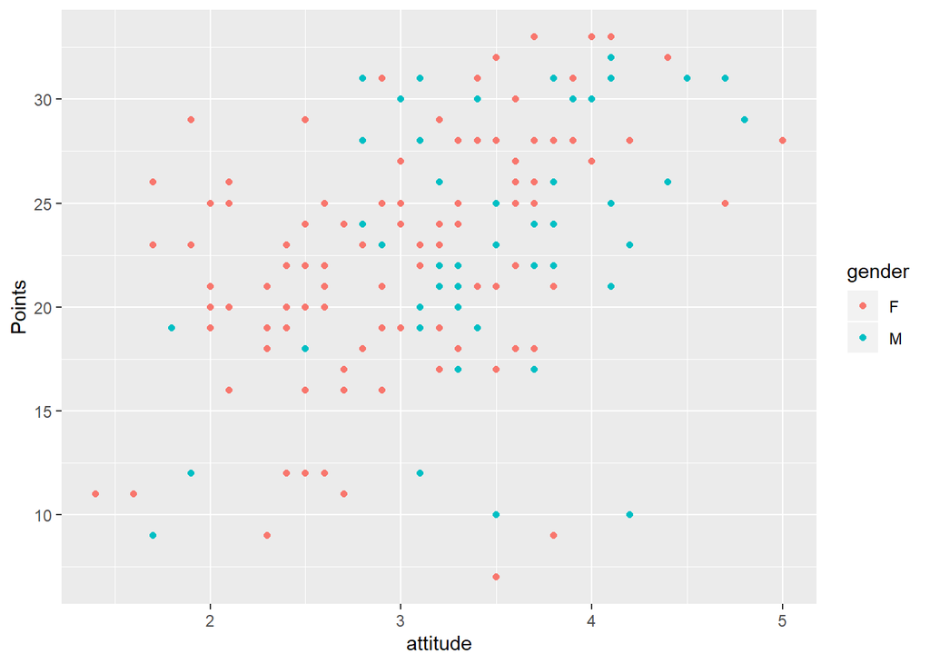

```r
#plot1:
#learning2014
library(ggplot2)
p1 <- ggplot(learning2014, aes(x = attitude, y = Points, col = gender))
p2 <- p1 + geom_point()
p2
```

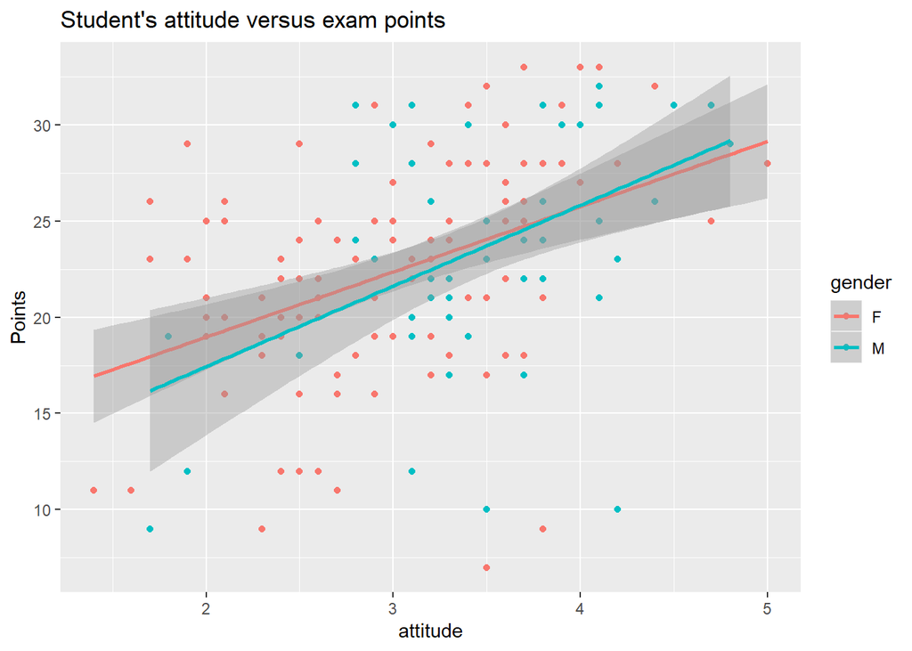

```r
p3 <- p2 + geom_smooth(method = "lm")
p4 <- p3 + ggtitle("Student's attitude versus exam points")
p4
```

- The data was gathered for a research exploring approaches to learning. The responders’ gender, age, and attitude, etc., were taken into account.
- Total of 166 observations of 7 variables. (For some reason at certain point it started showing 8 instead of 7 variables. I worked on that with Kimmo, he said to ignore it). :)
- First, I installed the ggplot2 (packages/install) and initialized plot. Exam points, attitude and gender were taken into account in the analysis.

-The plots are located under the name “plot”, in the “data” folder in my GitHub repository. Edit: for some reason they don’t show there, only codes are visible. The codes are working, and create beautiful models :)

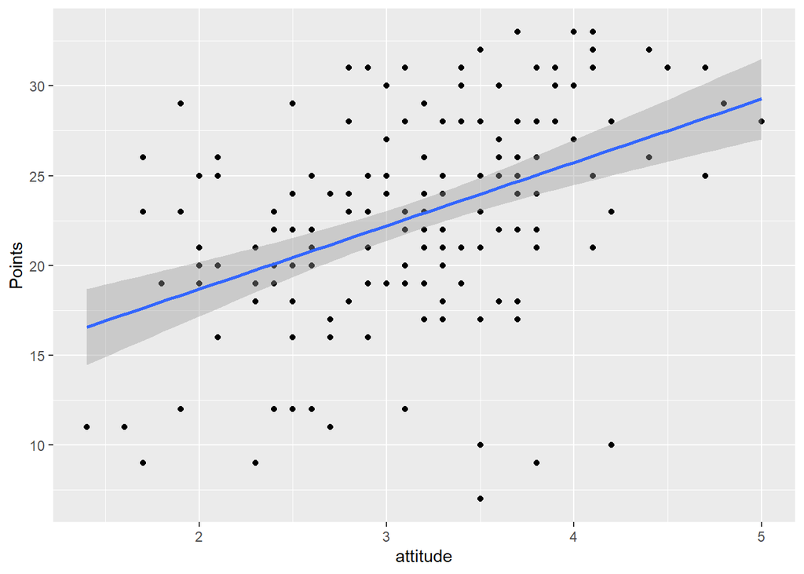

```r
#learning2014
library(ggplot2)
qplot(attitude, Points, data = learning2014) + geom_smooth(method = "lm")
```

```r
my_model <- lm(Points ~ attitude, data = learning2014)
summary(my_model)
```

```
##
## Call:
## lm(formula = Points ~ attitude, data = learning2014)
##
## Residuals:
##      Min       1Q   Median       3Q      Max
## -16.9763  -3.2119   0.4339   4.1534  10.6645
##
## Coefficients:
##             Estimate Std. Error t value Pr(>|t|)
## (Intercept)  11.6372     1.8303   6.358 1.95e-09 ***
## attitude      3.5255     0.5674   6.214 4.12e-09 ***
## ---
## Signif. codes:  0 '***' 0.001 '**' 0.01 '*' 0.05 '.' 0.1 ' ' 1
##
## Residual standard error: 5.32 on 164 degrees of freedom
## Multiple R-squared:  0.1906, Adjusted R-squared:  0.1856
## F-statistic: 38.61 on 1 and 164 DF,  p-value: 4.119e-09
```

Interpretation: it became visible that female participants were able to score higher than male participants when their attitude had lower value. In case of the male participants there is quite clear correlation between attitude and obtained points - statistically the higher the attitude, the higer the points. As for the female participants, the relationship between these vaiables is weaker. More participants scored better than predicted. Predictably there were cases of low points when the attitude was low, as well as there were high scores when the attitude was high. The statistical test is expressed by the slope of the line. In the performed analysis, it is different than 0, proving the usabilty of the model.

R-squared of the model answers the question how well the model represents the data. Put simply, it is defined by the difference between observed value (data; dots on the plot) and fitted value (predicting line; errors; residue). As Tuomo Nieminen explains, “the model is found by minimising the sum of squared residuals”.

```r
head(learning2014) # just to see the 6 first lines
```

```
##   X gender Age attitude     deep  stra     surf Points
## 1 1      F  53      3.7 3.583333 3.375 2.583333     25
## 2 2      M  55      3.1 2.916667 2.750 3.166667     12
## 3 3      F  49      2.5 3.500000 3.625 2.250000     24
## 4 4      M  53      3.5 3.500000 3.125 2.250000     10
## 5 5      M  49      3.7 3.666667 3.625 2.833333     22
## 6 6      F  38      3.8 4.750000 3.625 2.416667     21
```

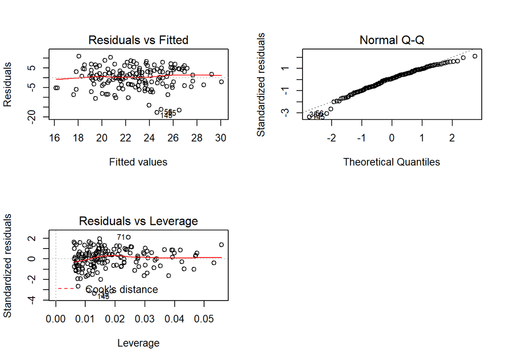

```r
my_model2 <- lm(Points ~ attitude + stra, data = learning2014)
par(mfrow = c(2,2))
plot(my_model2, which = c(1, 2, 5))
```

Residual vs. Fitted values verifies the assumptions of the model.

Residuals vs. Leverage shows which observations have impact on the model that could be defined as “unusually high”.